# The Effect of Vitamin C on Tooth Growth in Guinea Pigs

Derwin McGeary

09/20/2015

## Introduction

This is a brief analysis of the `ToothGrowth` dataset which is distributed with the R programming language.

From the [documentation](http://www.inside-r.org/r-doc/datasets/ToothGrowth) for that dataset:

> The response is the length of odontoblasts (teeth) in each of 10 guinea pigs at each of three dose levels of Vitamin C (0.5, 1, and 2 mg) with each of two delivery methods (orange juice or ascorbic acid).

We wish to know how the delivery method and dosage affect tooth length.

## Exploratory analysis

First we load the data into memory, check the structure, and do a preliminary plot to see what it looks like.

```r
data(ToothGrowth)
library(ggplot2)
library(knitr)
str(ToothGrowth)
```

```
## 'data.frame':    60 obs. of  3 variables:
##  $ len : num  4.2 11.5 7.3 5.8 6.4 10 11.2 11.2 5.2 7 ...
##  $ supp: Factor w/ 2 levels "OJ","VC": 2 2 2 2 2 2 2 2 2 2 ...
##  $ dose: num  0.5 0.5 0.5 0.5 0.5 0.5 0.5 0.5 0.5 0.5 ...
```

```r
kable(table(ToothGrowth$dose,ToothGrowth$supp))
```

|  | OJ | VC |
| --- | --- | --- |
| 0.5 | 10 | 10 |
| 1 | 10 | 10 |
| 2 | 10 | 10 |

```r
summary(ToothGrowth$len)
```

```
##    Min. 1st Qu.  Median    Mean 3rd Qu.    Max.
##    4.20   13.08   19.25   18.81   25.28   33.90
```

As expected, we have 60 observations (3 dosages, 0.5, 1, and 2; multiplied by 2 supplements, OJ and VC; and 10 guinea pigs per group). We know from the documentation that dosage is in `mg/day`, that `OJ` stands for Orange Juice and `VC` stands for Vitamin C, or ascorbic acid. The units of length are not specified there, but from [Crampton 1947](http://jn.nutrition.org/content/33/5/491.full.pdf) they appear to be microns. For the purposes of this analysis, the units aren’t critical.

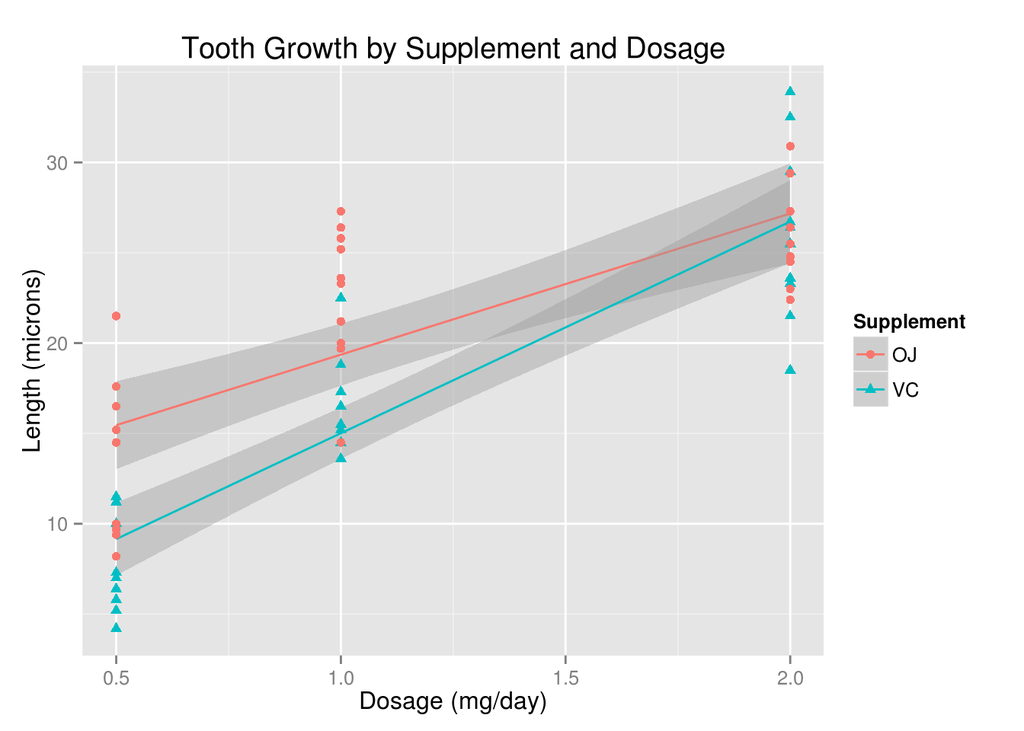

Looking at this graph it appears that there is a positive relationship between dosage and odontoblast length, and that orange juice results in more growth than plain vitamin C.

## Confidence Intervals and Hypothesis Testing

For all of these tests we will use a T-test, and the samples are assumed to be independent (not paired: these are different animals), and we will examine the p-value and 95% confidence interval.

### Dosage and Odontoblast Length

Here we will make three groups by dosage and take two comparisons: 0.5 mg/day versus 1 mg/day; and 1 mg/day versus 2 mg/day.

```r
d1 <- subset(ToothGrowth, dose==0.5); d2 <- subset(ToothGrowth, dose==1.0); d3 <- subset(ToothGrowth, dose==2.0)
halfvsone <- t.test(d1$len,d2$len, paired=FALSE,var.equal=FALSE)
onevstwo <- t.test(d2$len,d3$len, paired=FALSE,var.equal=FALSE)
halfvsone$conf.int
```

```
## [1] -11.983781  -6.276219
## attr(,"conf.level")
## [1] 0.95
```

```r
onevstwo$conf.int
```

```
## [1] -8.996481 -3.733519
## attr(,"conf.level")
## [1] 0.95
```

### Supplement and Odontoblast Length

Here we will combine all dosages together and group by which supplement was given.

```r
s1 <- subset(ToothGrowth, supp=="OJ"); s2 <- subset(ToothGrowth, supp=="VC")
stest <-t.test(s1$len,s2$len,paired=FALSE, var.equal=FALSE)
stest$conf.int
```

```
## [1] -0.1710156  7.5710156
## attr(,"conf.level")
## [1] 0.95
```

This shows a confidence level which does include zero, and the p-value of 0.0606345 is greater than 0.05 so we can that there is **no significant difference at the p=0.05 level** between the OJ and VC groups.

## Conclusion

There is a definite positive correlation between increased dosage and larger odontoblasts. This is using the T-test which makes the assumption that the distributions are roughly gaussian and independent (`iid`).